# Stat 480: Sample Exam - Solution

4/10/2018

The United States Geological Survey continuously monitors earth quakes and makes the corresponding data available to the public. A dataset containing all worldwide earth quakes for a time frame of 30 days is available at https://raw.githubusercontent.com/Stat579-at-ISU/stat579-at-isu.github.io/master/exams/data/earthquakes.csv.

You can find the accompanying codebook at [US Geology Survey](http://earthquake.usgs.gov/earthquakes/feed/v1.0/csv.php) (you should be able to answer all questions in this exam without the codebook).

1. Load the data into R. What is the time frame under consideration? How many earthquakes were there? When and where was the strongest earthquake? What was its magnitude?

```r
eq <- read.csv("https://raw.githubusercontent.com/Stat579-at-ISU/stat579-at-isu.github.io/master/exams/data/earthquakes.csv")

# time frame:
eq$Date <- lubridate::ymd(eq$Date)
summary(eq$Date)
```

```
##         Min.      1st Qu.       Median         Mean      3rd Qu.         Max.
## "2012-09-05" "2012-09-13" "2012-09-21" "2012-09-20" "2012-09-27" "2012-10-05"
```

```r
# the range of dates considered is between
min(eq$Date) # Sep 5 2012
```

```
## [1] "2012-09-05"
```

```r
# and
max(eq$Date) # Oct 5 2012
```

```
## [1] "2012-10-05"
```

```r
# number of earth quakes:
nrow(eq)
```

```
## [1] 7162
```

```r
# [1] 7162

eq[which.max(eq$Magnitude), c("Date", "Location")]
```

```
##           Date               Location
## 952 2012-09-30 9km WNW of San Agustin
```

```r
#          Date               Location
#952 2012-09-30 9km WNW of San Agustin
max(eq$Magnitude)
```

```
## [1] 7.3
```

```r
#[1] 7.3
```

2. The variable ‘Country’ contains country names or states (in the case of the US). Make the variable a factor variable. California is listed both as ‘CA’ and as ‘California’. Convert all elements in the variable from ‘CA’ to “California’.

```r
library(dplyr)
eq <- eq %>% mutate(
  Country = factor(Country)
)
levels(eq$Country)[11] <- "California"
sort(table(eq$Country), decreasing=TRUE)[1:5]
```

```
##
##             California                 Alaska British Virgin Islands
##                   2957                   1907                    479
##                 Nevada             Washington
##                    242                    207
```

```r
#            California                 Alaska British Virgin Islands
#                  2957                   1907                    479
#                Nevada             Washington
#                   242                    207
```

3. Which countries/states had the most earthquakes? List the top five.  
   Using ggplot2, create a barchart of country, sort by frequency of earthquakes.  
   Make sure that labels are readable in the barchart.

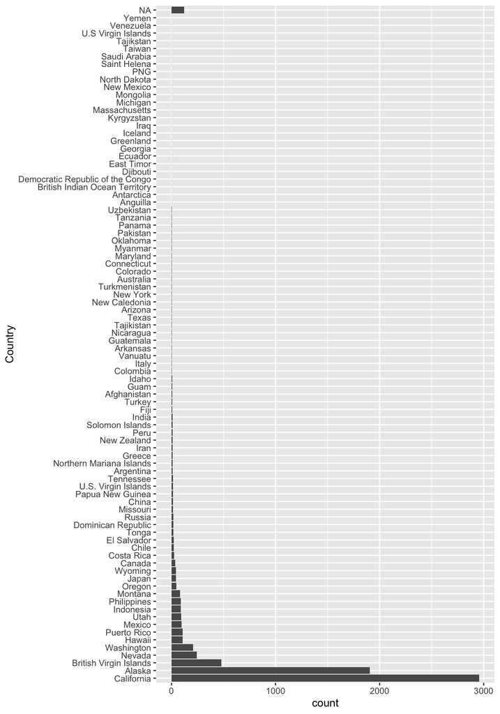

```r
library(ggplot2)
library(forcats)

eq %>% mutate(
  Country = fct_infreq(Country)) %>%
  ggplot(aes(x = Country)) + geom_bar() + coord_flip()
```

4. Create a new variable ‘Country10’ in the earthquake data that contains the country names for the ten countries/states with the highest number of earthquakes, and combines all other records in a category ‘Other’.  
   Show (using the ggplot2 package) boxplots of magnitude by country. Make sure to sort countries from lowest to highest median magnitude.

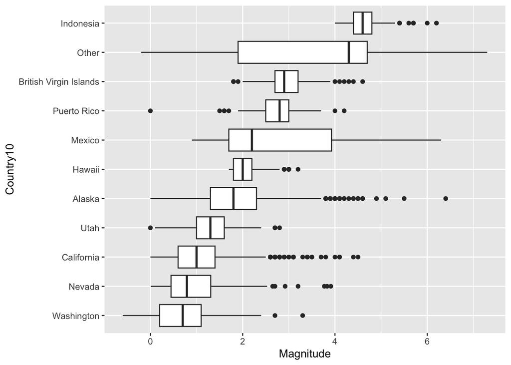

```r
# idea: create a table of earth quake frequency by country
# get the names of the top ten countries
top10 <- eq %>% filter(!is.na(Country)) %>%
  group_by(Country) %>% tally() %>% slice_max(n, n=10)

# use mutate to include a variable Country10
eq <- eq %>% mutate(
  Country10 = ifelse(Country %in% top10$Country, as.character(Country), "Other")
)


eq %>% mutate(
  Country10 = fct_reorder(Country10, Magnitude)
) %>%
  ggplot(aes(x = Country10, y = Magnitude)) + geom_boxplot() + coord_flip()
```

5. Draw a histogram of magnitude of earthquakes - make sure to not get a warning message. Describe the shape of the density.  
   Use the histogram to pick a suitable cutoff between ‘small’ and ‘large’ earthquakes.

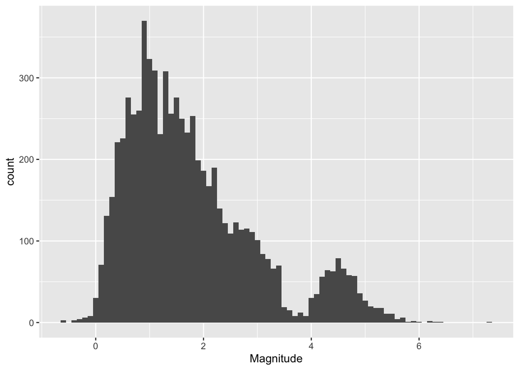

```r
eq %>% ggplot(aes(x = Magnitude)) + geom_histogram(binwidth = 0.1)
```

```r
# let's use 4 as the cutoff between 'small' and 'large' earth quakes

eq$size <- c("small", "large")[(eq$Magnitude >= 4)+1]
```

6. Load the `maps` package and extract a world map (hint: think of `map_data`). Plot the world map using a polygon layer. Set the fill color to `grey50`. Add a layer of points to the map showing the locations of earthquakes use color to distinguish between small and large earthquakes.

Describe what you see.

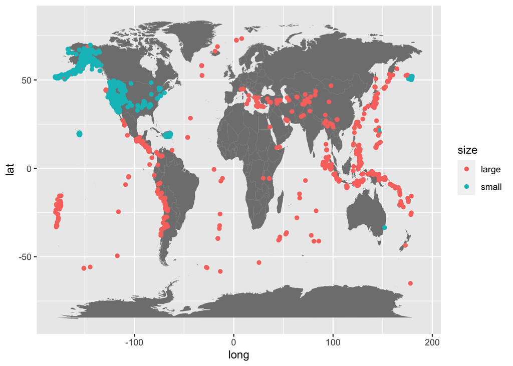

```r
library(maps)
world <- map_data("world")
worldmap <- world %>% ggplot(aes(x = long, y = lat, group=group)) +
  geom_polygon(fill = "grey50")

worldmap + geom_point(aes(x = Longitude, y = Latitude, colour = size, group=1), data = eq)
```

```r
# US has most of small earthquakes
```

7. Using dplyr, determine for each date
- the number of earthquakes,
- their average magnitude,
- the name of the country/state in which most of them happened that day.

  Based on the summary data, draw a single chart that incorporates all of the above information.

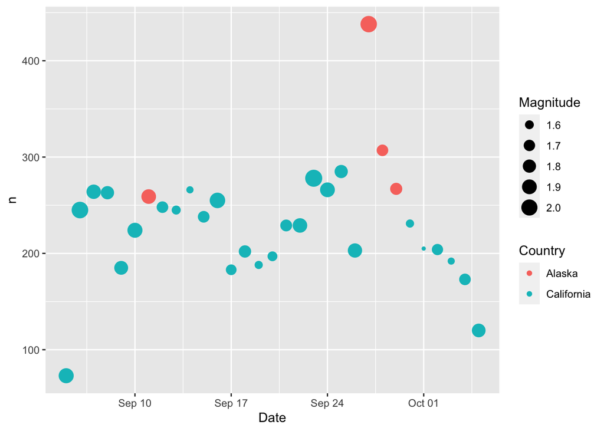

```r
eq.stats <- eq %>% group_by(Date) %>% summarize(
    n = n(),
    Magnitude = mean(Magnitude),
    Country = names(sort(table(Country), decreasing=TRUE))[1]
)

eq.stats %>%
  ggplot(aes(x = Date, y = n, colour=Country, size=Magnitude)) +
  geom_point()
```